# 4. Rendering System

This article goes over the motivation behind the parts of the rendering system. It builds up from simple console printing to rendering animations ingame.

Example usage of the rendering functions can be found in their documentation, e.g. `?render.scene`.

## 1. Goals

Game with graphics need a way to display their graphics. rcade is intended to run live-input games at relatively high fps (frames per second), so it needs a graphical system capable of redrawing itself at the desired framerate. Past achieving that, it’s a matter of getting as high a resolution as feasible.

## 2. Console Graphics

R plotting is far too slow to fulfill our needs. Instead, we turn to a canonical apporach— rendering via the console. Pixels can be printed as characters in the appropriate locations, giving a low-resolution but highly usable medium for rendering images. In fact, RStudio allows you to zoom out a considerable amount, allowing the console to fit upwards of 800x600 characters.

A couple issues come up. First, characters are much taller than they are wide, so we use pairs of characters—usually brackets: `[]`—to create square pixels.

### 2.1 Pixel Art in the Console

Printing to the console like this is quite simple. Strings like this are quickly interpreted by users as imagery:

**Example [click to expand]**

```r
cat('
  []  []
  []  []

[]      []
  [][][]
')
```

But we run into an issue. Art can be printed to the console, but there’s no guarantee it shows up in the right position vertically…

Luckily, clearing the console means that the next message will always show up in the same place— we can just clear the console every time we draw. RStudio supports this with the escape character `cat('\f')`[^1], though R.app unfortunately doesn’t.

### 2.2 Storing Pixel Art

If we want to print lots of images, we can’t just store everything as strings— it would be a nightmare to work with because of how clunky strings are to edit. Instead, we can write a function, `render.matrix()`, to convert directly from a bitmap matrix to a drawable string:

**`render.matrix`**

```r
render.matrix = function(M, palette = c('  ', '[]', '  ')){
  #we assume the bitmap to be positive integers

  #attach a line of -1 values on the rightmost column to turn into newlines
  M = rbind(t(M),-1) #transpose to match the orientation of print(M)

  #add two to make all values work as vector indices
  M = M + 2

  #convert matrix to vector of strings using its values as indices
  str = c('\n',palette)[M]

    cat(str, sep='') #collapse vector and print
}

render.matrix(matrix(c(0,0,1,0,0,0,0,1,1,1,0,1,0,0,0,1,1,1,0,1,0,0,0,1,0,0,1,0), ncol = 7))
```

```
#>     []  []
#>     []  []
#> []          []
#>   [][][][][]
```

`palette` defines how we convert bitmap values to character pixels— by default, `1` encodes filled (black) pixels and `0` and `2` are white. Values of `0` are used elsewhere in the rendering system to represent transparency, but assume a white background here and draw them as white.

## 3. Sprites

So `render.matrix()` lets us print pixel art to the console if we have a matrix that encodes it. This package calls such a matrix a **sprite**.

**Example**

```r
#A sprite is anything that can be printed by render.matrix():
sprite = matrix(c(0,0,1,0,0,0,0,1,1,1,0,1,0,0,0,1,1,1,0,1,0,0,0,1,0,0,1,0), ncol = 7)

print(sprite)
```

```
#>      [,1] [,2] [,3] [,4] [,5] [,6] [,7]
#> [1,]    0    0    1    0    1    0    0
#> [2,]    0    0    1    0    1    0    0
#> [3,]    1    0    0    0    0    0    1
#> [4,]    0    1    1    1    1    1    0
```

```r
render.matrix(sprite)
```

```
#>     []  []
#>     []  []
#> []          []
#>   [][][][][]
```

Typically, the game stores and handles sprites directly (as matrices), and the game dev is expected to generate them on their own. The package provides a convenient tool for this: `render.makesprite()`.

### 3.1 Sprite Creation

`render.makesprite()` converts user text to a sprite as intuitively as possible. The goal of this function is to remove the need for confusing matrix manipulation, and to follow the principle of WYSIWYG for maximal convenience: “what you see is what you get”.

**Example**

```r
circle = render.makesprite('
  OOO
 O   O
O     O
O     O
O     O
 O   O
  OOO
')

render.matrix(circle)
```

```
#>     [][][]
#>   []      []
#> []          []
#> []          []
#> []          []
#>   []      []
#>     [][][]
```

The limitation is that character strings will look a bit different from square pixels, but overall I’ve found the function to be extremely useful.

Sometimes, it’s easier to create a sprite manually as a matrix. This is especially useful for geometric or procedural shapes:

**Example**

```r
box = matrix(1,8,16)
box[2:(nrow(box) - 1), 2:(ncol(box) - 1)] = 0

render.matrix(box)
```

```
#> [][][][][][][][][][][][][][][][]
#> []                            []
#> []                            []
#> []                            []
#> []                            []
#> []                            []
#> []                            []
#> [][][][][][][][][][][][][][][][]
```

## 4. Drawing Multiple Things at Once

`render.matrix()` lets us render an individual sprite to the console. The natural next step is to somehow **combine** sprites so they can be drawn together in one image.

The general approach to this is to take a big, empty, rectangular ‘background’ sprite, and edit in our sprites:

**Example**

```r
sprite = render.makesprite('
 O O
 O O

O   O
 OOO
')

background = matrix(0,12,10)

#paste in sprites
background[1:5,1:5] = sprite
background[2 + 1:5, 5 + 1:5] = sprite
background[7 + 1:5, 3 + 1:5] = sprite

render.matrix(background)
```

```
#>   []  []
#>   []  []
#>             []  []
#> []      []  []  []
#>   [][][]
#>           []      []
#>             [][][]
#>         []  []
#>         []  []
#>
#>       []      []
#>         [][][]
```

The problem with this is that replacing values directly with `matrix[a:b,c:d]` will always overwrite the original values. We can get around this with code like this to allow for sprites with transparency— we just encode transparent pixels as a value of `0`.

```r
  overwrite = sprite
  overwrite[sprite == 0] = matrix[a:b,c:d][sprite == 0]
  #replace values of 0 with the value underneath

  matrix[a:b,c:d] = overwrite
```

**Example**

```r
background = matrix(0,9,9)

background[1:7,1:7] = circle

overwrite = circle
overwrite[circle == 0] = background[1 + 1:7,2 + 1:7][circle == 0]
background[1 + 1:7,2 + 1:7] = overwrite

render.matrix(background)
```

```
#>     [][][]
#>   []    [][][]
#> []    []    [][]
#> []  []      []  []
#> []  []      []  []
#>   [][]    []    []
#>     [][][]    []
#>         [][][]
#>
```

This whole process is automated by `render.overlay()`, which also clips the sprite to ensure that everything is kept within the bounds of the matrix.

**Example**

```r
background = matrix(0,9,14)

background = render.overlay(background, circle, 1, 1)
background = render.overlay(background, circle, 3, 3)
background = render.overlay(background, circle, 11, 1)

render.matrix(background)
```

```
#>     [][][]              [][]
#>   []      []          []
#> []      [][][]      []
#> []    []    [][]    []
#> []  []      []  []  []
#>   [][]    []    []    []
#>     [][][]      []      [][]
#>       []      []
#>         [][][]
```

## 5. Layers and the Scene

Now that we can combine sprites, we run into the issue of convenient **ordering**. Which sprites should be drawn on top, and how do we achieve that?

rcade addresses this with `render.scene()`. We create a ‘scene’ object containing **layers**, each of which is their own `background` from the previous section. The engine draws sprites onto specific layers, and then finally takes all the layers and overlays them one-by-one to produce the final matrix to be drawn.

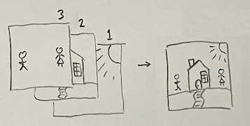

`render.scene()` stacks individuals layers in a scene into a single sprite matrix to be drawn by `render.matrix()`.

To draw a sprite onto a layer, we use `render.sprite()`, which is really just a wrapper for `render.overlay(layer,sprite)`.

### 5.1 The Inversion Layer

In monochrome displays, you’ll sometimes run into the issue where something important, like text, is drawn over a black background and becomes impossible to see. A simple fix is to, rather than drawing the text as set color, just allow it to invert the color it’s drawn on— that way it’ll always be visible[^2].

rcade implements this with a dedicated `scene` layer called `scene$layers$invert`, which is drawn last and inverts anything it covers. This uses the `invert` argument of `render.overlay()`.

**Example**

```r
scene = list(width=48, height=12)
block = upper.tri(matrix(1,12,32))[12:1,]

scene = render.sprite(scene,block,12,1)

txt = render.text('inversion\nof colors')

scene = render.sprite(scene,txt,2,1,layer='invert')

render.scene(scene)
```

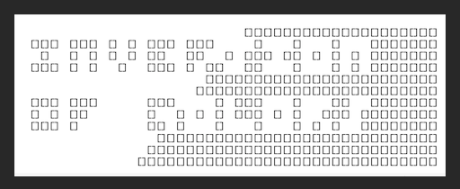

Zoom out if this is hard to read.

## 6. Drawing the RAM

The game rendering process involves drawing every game object onto one scene. This is automated by `render.ram()`, which is called every frame— see `vignette("timing")`.

In this function, a `scene` object is created, and then each game object (in `RAM$objects`) is drawn to it with `render.sprite()`.

### 6.1 Sprites in ROM

By convention, sprites/images are stored in ROM when possible.[^3] They are stored by name in `ROM$sprites`, and referenced during the rendering process.

### 6.2 Object Drawing Specifics

Object drawing is handled by `render.object()`, which figures out how and where to draw the object with `render.sprite()`.

Objects are only drawn if they have a `$spritename`, which indicates which sprite they use. This is a character string corresponding to a sprite matrix in `ROM$sprites`— then `render.object()` retrieves the sprite from `ROM$sprites` and feeds it into `render.sprite()`.

Objects have quite a few optional properties, listed in `?render.object`. These control things like position and whether or not this particular object should swap around the colors in its sprite. ‘palette swapping’ of the colors like this is an easy way to increase the variety of images in a game without needing to make new sprites.

**Example**

```r
sprite = render.makesprite('

 ...
.O=O.
.....
 ===

',lookup = c(' ' = 0, '.' = 1, '=' = 2, 'O' = 3))

render.matrix(sprite, palette=c('  ','..','==','()'))
```

```
#>
#>   ......
#> ..()==()..
#> ..........
#>   ======
#>
```

```r
render.matrix(sprite, palette=c('  ','..','++','\\/'))
```

```
#>
#>   ......
#> ..\/++\/..
#> ..........
#>   ++++++
#>
```

```r
render.matrix(sprite, palette=c('  ','||','MM','()'))
```

```
#>
#>   ||||||
#> ||()MM()||
#> ||||||||||
#>   MMMMMM
#>
```

### 6.3 Custom Drawing Code

It is often useful to override this basic drawing behavior— for example, if an object’s sprite should be generated procedurally rather than copying from a static sprite in `ROM$sprites`. This can be done by defining `obj$draw()`, which will run instead of the regular code in `render.object()`.

Note that `obj$draw()` should return the `scene`, and thus must not include any code that changes values in the object itself; those changes should occur in game code in `ROM$custom()` (see `vignette("engine")`).

## 7. Animations

This is facilitated by calling `render.animate()` when we retrieve an object’s sprite in `render.object()`. For sprites we want to animate, instead of storing just the pixel art matrix, we store a list containing each frame of animation and some other information about the animation. `render.animate()` then parses these to figure out what frame of animation it should return.

We can also specify whether an animation should loop or transition to a different sprite after completing, by giving the list a value for `next_animation`.

So for the game dev, all that’s needed to animate a sprite is to store it as a complex sprite in `ROM$sprites` and add some metadata about the animation. Very convenient! Sprite animations can also be tested with `render.test_animation` to ensure they look as they should.

## 8. Text

Now for the topic of rendering a piece of text ingame. We could just `render.sprite()` each character individually, but this is needlessly ineffecient; instead, the best solution is to combine all the characters into one sprite and render that in a single `render.sprite()` call. This is the purpose of `render.text()`.

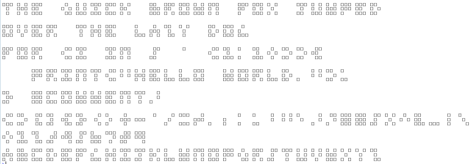

### 8.1 Fonts

But first, how should store the sprites for each character? rcade handles these pretty simply— it has *font* objects which contain some information about the size/spacing of the characters, and also contain a list of sprites for each character. `?render.makefont` provides more detail on this, and inspecting `View(fonts.3x3)` may be useful as well.

### 8.2 render.text()

The basic functionality of `render.text()` is stitching together character sprites with the desired (or default) spacing. It outputs a sprite, to put in `ROM$sprites` or draw on the fly in `obj$draw()`. Putting text on the inversion layer (with `render.sprite(...layer = 'invert')` may be helpful to ensure that the text is readable on both black or white backgrounds.

Additionally, some code is included to provide the option to wrap words to fit in a given width of pixels, and align them to the left/right/center.[^4]

Here’s an example of `render.text()`’s stitching:

**Example**

```r
#manually stitching letters with a 1-wide gap between
render.matrix(
  cbind(
    fonts.3x3$sprites$T,
    matrix(0,3,1),
    fonts.3x3$sprites$E,
    matrix(0,3,1),
    fonts.3x3$sprites$X,
    matrix(0,3,1),
    fonts.3x3$sprites$T
  )
)
```

```
#> [][][]  [][][]  []  []  [][][]
#>   []    [][]      []      []
#>   []    [][][]  []  []    []
```

```r
#render.text() does this automatically
render.matrix(
  render.text('text', kerning = 1)
)
```

```
#>
#> [][][]  [][][]  []  []  [][][]
#>   []    [][]      []      []
#>   []    [][][]  []  []    []
#>
```

`?render.text` provides some more examples of its capabilities.

## 9. Rendering Pipeline

### 9.1 Setup

1. We start with an object called Blueberry. It’s at the xy coordinates (5,6) and is on layer 5 of the game scene.
2. Blueberry is stored in RAM as the list `RAM$objects$blueberry`, and has the following elements:

```
$x: 5
$y: 6
$spritename: 'blueberry'
$layer: 5
```

3. We also have a corresponding sprite stored as `RAM$ROM$sprites$blueberry` as a simple matrix.

## 10. Flickering

The timing system (`vignette("timing")`) is robust enough that slow draw times (i.e. for large resolutions) won’t impact the fluidity of gameplay. However, the basic drawing system has a big flaw: flickering.

`base::cat()` prints output in large chunks of characters, and each chunk takes a tiny bit of time to print. (Try `cat(rep(1,100000))`: it takes a good second for the whole output to finish printing). This creates a problem: when we clear the console with `'\f'`, the first chunk of characters are immediately printed to fill the blank space, but it takes a split second for the rest of the characters to get drawn. The background is blank during that split second, so we end up with a brief flicker of white on every frame that gets stronger the more characters (including whitespaces!) are drawn.

This has several benefits: in addition to removing flickering, this lets us animate the game without having to clear the console with `'\f'`— which means it can even run in R.app!

I discovered this workaround very late into working on rcade: I plan on making it the package’s default, but haven’t gotten around to it yet.

[^1]: Try it! It’s very useful in general R work along with `cat('\r')`, which overwrites the current line (and is how things like loading bars are animated).
[^2]: Unless you draw it on a patterned surface. In that case, an opaque outline (like a highlighter or shadow) is needed to make the text pop.
[^3]: This is because if we had a particularly large image file, as images tend to be nowadays, it would be expensive to store and copy constantly in RAM. The same was true back in the day; graphics have always taken up a large portion of games’ filesize.
[^4]: Though this code could use some improvement. It does its job but isn’t very robust— I figured it was already too niche to warrant more attention. Apparently r also has a dedicated `base::strwrap()` function for this already…`